# **CA4 @ AI Spring 2025**

# Convolutional vs. Fully Connected Neural Networks

- **Name:** Ali Borzoozadeh
- **Student ID:** 810102410

Your submission should be named using the following format: `AI_CA4_LASTNAME_STUDENTID.ipynb`.

*How to do this problem set:*

- Some questions require writing Python code and computing results, and the rest of them have written answers. For coding problems, you will have to fill out all code blocks that say `YOUR CODE HERE`.
- For text-based answers, you should replace the text that says `WRITE YOUR ANSWER HERE` with your actual answer.

If you have any further questions or concerns, contact the TAs via email or Telegram.

# Introduction

In this assignment, you will compare fully connected neural networks with convolutional neural networks to evaluate whether convolutional architectures offer superior performance—and understand the reasons behind any observed differences.

**Important Note:**

Before you begin, please make sure to review the accompanying PyTorch tutorial provided alongside this file.

## Colab Setup

If you are running this notebook on Google Colab, you can mount your Google Drive using the following code to access or upload files directly from your Drive.

```python
# from google.colab import drive
# import os

# drive.mount('/content/drive')

# GOOGLE_DRIVE_PATH = os.path.join('drive', 'My Drive', 'AIS25-CA4')
# os.chdir(GOOGLE_DRIVE_PATH)
```

## Device

As demonstrated in the PyTorch tutorial, PyTorch enable you to run your code on GPU to accelerate computations.

```python
import torch
device = 'cuda' if torch.cuda.is_available() else 'cpu'
device
```

```
'cuda'
```

# Dataset

## Transforms & Dataset & Dataloader

Here, you should download and load the dataset with the desire transforms. After that, you should split train dataset to train and validation sets. Finally, define the dataloaders for `train`, `validation` and `test`

```python
classes = ['plane', 'car', 'bird', 'cat', 'deer', 'dog', 'frog', 'horse', 'ship', 'truck']
```

```python
from torchvision import transforms

transform_train = transforms.Compose([
    transforms.ToTensor(),
    transforms.Normalize((0.491, 0.482, 0.446), (0.247, 0.243, 0.261)),
])
transform_test = transforms.Compose([
    transforms.ToTensor(),
    transforms.Normalize((0.491, 0.482, 0.446), (0.247, 0.243, 0.261)),
])
```

```python
from torch.utils.data import random_split
from torch.utils.data import DataLoader
import torchvision

batch_size = 512

initial_trainset = torchvision.datasets.CIFAR10(root='./data', train=True, download=True, transform=transform_train)
testset = torchvision.datasets.CIFAR10(root='./data', train=False, download=True, transform=transform_test)

trainset, valset = random_split(initial_trainset, [45000, 5000])

trainloader = DataLoader(trainset, batch_size=batch_size, shuffle=True, num_workers=2, pin_memory=True)
valloader = DataLoader(valset, batch_size=batch_size, shuffle=False, num_workers=2, pin_memory=True)
testloader = DataLoader(testset, batch_size=batch_size, shuffle=False, num_workers=2, pin_memory=True)
```

Why not use the same `Dataset` format and make it in `DataLoader` format?

**Dataset**

- A `Dataset` is an object that **stores and provides access to our data** (images, labels, etc.).
- It defines **how to get a single sample** (via `__getitem__`) and **how many samples** there are (via `__len__`).
- We can use any custom logic for loading, transforming, or generating data.

**DataLoader**

- A `DataLoader` **wraps a Dataset** and provides an **iterator** over the data.
- It handles **batching**, **shuffling**, and **parallel loading** (with `num_workers`).
- It makes training and evaluation efficient and easy.

**Why not just use Dataset?**

- If we only use a `Dataset`, we have to manually handle batching, shuffling, and parallel loading, which is inefficient and error-prone.
- `DataLoader` automates these tasks, making your code cleaner and your training faster.

## Visualization

Visualize 5 random images from each class in different columns

- **Hint**: You can use `plt.subplots` for visualization

```python
# inverse the normilize transform to restore the original data
import torch

class UnNormalize(object):
    def __init__(self, mean, std):
        self.mean = torch.tensor(mean)
        self.std = torch.tensor(std)

    def __call__(self, tensor, gray=False, coeff=(0.3, 0.59, 0.11)):
        """
        Args:
            tensor (Tensor): Tensor image of size (C, H, W) to be unnormalized.
        Returns:
            Tensor: Unnormalized image.
        """

        tensor = tensor.clone()
        for t, m, s in zip(tensor, self.mean, self.std):
            t.mul_(s).add_(m)
        return tensor

norminv = UnNormalize(mean=(0.491, 0.482, 0.446), std=(0.247, 0.243, 0.261))
```

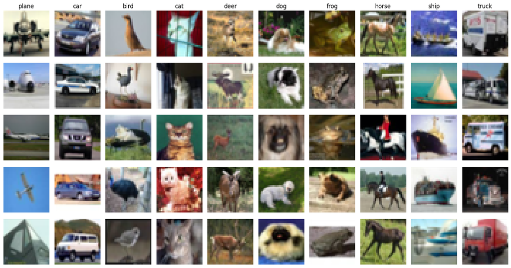

```python
import matplotlib.pyplot as plt
import numpy as np

images_per_class = {i: [] for i in range(10)}
labels_per_class = {i: [] for i in range(10)}

for img, label in trainset:
    if len(images_per_class[label]) < 5:
        images_per_class[label].append(img)
        labels_per_class[label].append(label)
    if all(len(images_per_class[i]) == 5 for i in range(10)):
        break

fig, axs = plt.subplots(5, 10, figsize=(15, 8))
for class_idx in range(10):
    for img_idx in range(5):
        img = norminv(images_per_class[class_idx][img_idx])
        img = img.permute(1, 2, 0).numpy()
        img = np.clip(img, 0, 1)
        axs[img_idx, class_idx].imshow(img)
        axs[img_idx, class_idx].axis('off')
        if img_idx == 0:
            axs[img_idx, class_idx].set_title(classes[class_idx])
plt.tight_layout()
plt.show()
```

# Fully Connected Neural Netwrok

Your first task is to build a fully connected neural network with PyTorch. To achieve this, it is recommended that you familiarize yourself with the following PyTorch components and incorporate them into your network architecture:

- [`nn.Module`](https://docs.pytorch.org/docs/stable/generated/torch.nn.Module.html)
- [`nn.Sequential`](https://docs.pytorch.org/docs/stable/generated/torch.nn.Sequential.html)
- [`nn.Linear`](https://docs.pytorch.org/docs/stable/generated/torch.nn.Linear.html)
- [`nn.ReLU`](https://docs.pytorch.org/docs/stable/generated/torch.nn.ReLU.html)
- [`nn.Dropout`](https://docs.pytorch.org/docs/stable/generated/torch.nn.Dropout.html)
- [`nn.Flatten`](https://docs.pytorch.org/docs/stable/generated/torch.nn.Flatten.html)

In the provided template below, the final layer of the model should be defined separately and assigned the name `linear`, as it will be referenced in a later section of this assignment.

To ensure a fair comparison with convolutional neural networks (CNNs), both models should have approximately the same number of trainable parameters. Specifically, the fully connected model should contain **33,500,000 ± 500,000** trainable parameters.

You will calculate the exact number of trainable parameters in the following subsection to ensure this requirement is met.

```python
import torch
import numpy as np
import torchvision
import torch.nn as nn
import math
from torchvision import transforms

class FullyConnectedNetwork(nn.Module):
    def __init__(self, input_shape=(3, 32, 32), num_classes=10):
        super(FullyConnectedNetwork, self).__init__()

        # Layers: 3072 -> 4096 -> 3072 -> 2048 -> 1024 -> 10

        self.flatten = nn.Flatten()
        self.fc_layers = nn.Sequential(
            nn.Linear(3*32*32, 4096),
            nn.ReLU(),
            nn.Dropout(0.2),
            nn.Linear(4096, 3072),
            nn.ReLU(),
            nn.Dropout(0.2),
            nn.Linear(3072, 2048),
            nn.ReLU(),
            nn.Dropout(0.2),
            nn.Linear(2048, 1024),
            nn.ReLU(),
            nn.Dropout(0.2),
        )
        self.linear = nn.Linear(1024, num_classes)

    def forward(self, x):
        x = self.flatten(x)
        x = self.fc_layers(x)
        x = self.linear(x)
        return x
```

Dropout is a regularization technique used in neural networks to prevent overfitting. During training, dropout randomly "drops out" (sets to zero) a fraction of the neurons' outputs in a layer at each forward pass. This means that each update does not rely on the same set of features, forcing the network to learn more robust and generalizable representations.

**How it works:**

- For each training batch, dropout randomly disables a specified percentage (e.g., 20%) of neurons in the layer.
- During inference (evaluation), dropout is turned off, and all neurons are used, but their outputs are scaled to account for the dropout rate during training.

**Impact on the model:**

- **Reduces overfitting:** By preventing co-adaptation of neurons, dropout helps the model generalize better to unseen data.
- **Acts as model averaging:** Each dropout mask can be seen as training a different sub-network, so the final model is an average of many sub-networks.
- **May slow convergence:** Training with dropout can require more epochs to converge, but usually results in better generalization.

In summary, dropout improves the robustness and generalization of neural networks, especially in large models prone to overfitting.

## Trainable params

Based on the defined architecture, manually calculate the total number of trainable parameters:

**Layer sizes:**

- Input: 3×32×32 = 3072
- 1st Linear: 3072 → 4096
- 2nd Linear: 4096 → 3072
- 3rd Linear: 3072 → 2048
- 4th Linear: 2048 → 1024
- Output Linear: 1024 → 10

**Parameter calculation for each layer:**

- Linear layers have (input_features × output_features) + output_features (bias) parameters.
1. **First Linear (3072 → 4096):**
   - Weights: 3072 × 4096 = 12,582,912
   - Bias: 4096
   - Total: 12,587,008
2. **Second Linear (4096 → 3072):**
   - Weights: 4096 × 3072 = 12,582,912
   - Bias: 3072
   - Total: 12,585,984
3. **Third Linear (3072 → 2048):**
   - Weights: 3072 × 2048 = 6,291,456
   - Bias: 2048
   - Total: 6,293,504
4. **Fourth Linear (2048 → 1024):**
   - Weights: 2048 × 1024 = 2,097,152
   - Bias: 1024
   - Total: 2,098,176
5. **Output Linear (1024 → 10):**
   - Weights: 1024 × 10 = 10,240
   - Bias: 10
   - Total: 10,250

**Sum:**  
12,587,008 + 12,585,984 + 6,293,504 + 2,098,176 + 10,250 = **33,574,922**

**Total trainable parameters: 33,574,922**

Once you have completed your hand calculation, you can verify your result by running the following cell:

```python
from torchsummary import summary
summary(FullyConnectedNetwork().to(device), input_size=(3, 32, 32));
```

```
----------------------------------------------------------------
        Layer (type)               Output Shape         Param #
================================================================
           Flatten-1                 [-1, 3072]               0
            Linear-2                 [-1, 4096]      12,587,008
              ReLU-3                 [-1, 4096]               0
           Dropout-4                 [-1, 4096]               0
            Linear-5                 [-1, 3072]      12,585,984
              ReLU-6                 [-1, 3072]               0
           Dropout-7                 [-1, 3072]               0
            Linear-8                 [-1, 2048]       6,293,504
              ReLU-9                 [-1, 2048]               0
          Dropout-10                 [-1, 2048]               0
           Linear-11                 [-1, 1024]       2,098,176
             ReLU-12                 [-1, 1024]               0
          Dropout-13                 [-1, 1024]               0
           Linear-14                   [-1, 10]          10,250
================================================================
Total params: 33,574,922
Trainable params: 33,574,922
Non-trainable params: 0
----------------------------------------------------------------
Input size (MB): 0.01
Forward/backward pass size (MB): 0.26
Params size (MB): 128.08
Estimated Total Size (MB): 128.35
----------------------------------------------------------------
```

## Train

### Model Instantiation

Create an instance of your model and move it to your selected device (CPU or GPU). Refer to the PyTorch-tutorial notebook for guidance on how to perform this operation.

```python
model = FullyConnectedNetwork().to(device)
```

### Criterion & Optimizer

To train a neural network, we require a **loss function** (referred to as the *criterion*) to quantify the difference between the model's predictions and the true labels. This loss is then used to compute the gradients of the model parameters.

In addition, an **optimization algorithm** is needed to update the model's parameters using the calculated gradients, in order to minimize the loss over time.

You are encouraged to read about the following PyTorch components:

- [`nn.CrossEntropyLoss`](https://docs.pytorch.org/docs/stable/generated/torch.nn.CrossEntropyLoss.html)
- [`torch.optim.Adam`](https://docs.pytorch.org/docs/stable/generated/torch.optim.Adam.html)

```python
criterion = torch.nn.CrossEntropyLoss()
optimizer = torch.optim.Adam(model.parameters(), lr=0.001)
```

- CrossEntropyLoss is used for multi-class classification because it directly optimizes for correct class probabilities.
- Adam optimizer adapts learning rates for each parameter using gradient history, while SGD uses a fixed learning rate and only the current gradient. Adam often converges faster and is more robust to hyperparameter choices.

### Train loop

Train your model

Tasks:

- Things that are needed to be printed in each epoch:
  - Number of epoch
  - Train loss
  - Train accuracy
  - Validation loss
  - Validation accuracy
- save train/validation loss and accuracy (of each epoch) in an array for later usage

```python
def train_epoch(net: torch.nn.Module, criterion: torch.nn.Module, optimizer: torch.optim.Optimizer ,dataloader: torch.utils.data.DataLoader):
    """
    Trains the neural network for a single epoch.

    Args:
        net (torch.nn.Module): The neural network model to be trained.
        criterion (torch.nn.Module): The loss function used to compute the training loss.
        optimizer (torch.optim.Optimizer): The optimization algorithm used to update model parameters.
        dataloader (torch.utils.data.DataLoader): DataLoader providing the training data in batches.

    Returns:
        tuple:
            - avg_loss (float): The average loss across all batches in the epoch.
            - accuracy (float): The classification accuracy (in percentage) over the entire dataset for the epoch.

    Notes:
        - The `criterion` computes the loss between the model's predictions and the true labels.
        - The `optimizer` updates the model's parameters based on the computed gradients to minimize the loss.
    """

    net.train()
    running_loss = 0.0
    correct = 0
    total = 0

    for inputs, labels in dataloader:
        inputs, labels = inputs.to(device), labels.to(device)
        optimizer.zero_grad()
        outputs = net(inputs)
        loss = criterion(outputs, labels)
        loss.backward()
        optimizer.step()

        running_loss += loss.item() * inputs.size(0)
        _, predicted = outputs.max(1)
        correct += predicted.eq(labels).sum().item()
        total += labels.size(0)

    avg_loss = running_loss / total
    accuracy = 100.0 * correct / total
    return avg_loss, accuracy

def eval_epoch(net: torch.nn.Module, criterion: torch.nn.Module, dataloader: torch.utils.data.DataLoader, test_mode: bool = False):
    """
    Evaluates the neural network on a validation or test dataset for one epoch.
    """
    net.eval()
    running_loss = 0.0
    correct = 0
    total = 0

    with torch.no_grad():
        for inputs, labels in dataloader:
            inputs, labels = inputs.to(device), labels.to(device)
            outputs = net(inputs)
            loss = criterion(outputs, labels)
            running_loss += loss.item() * inputs.size(0)
            _, predicted = outputs.max(1)
            correct += predicted.eq(labels).sum().item()
            total += labels.size(0)

    avg_loss = running_loss / total
    accuracy = 100.0 * correct / total
    return avg_loss, accuracy
```

As previously mentioned, ensuring a fair comparison between models requires consistency in certain aspects of the training setup. One key factor is the number of **trainable parameters**, and another is the number of times the model processes the entire dataset—referred to as an **epoch**.

To maintain consistency in training duration across models, **do not modify** the `epochs` variable defined below.

```python
epochs = 60 # Do not modify

history = {'train_loss':[], 'train_acc':[], 'val_loss':[], 'val_acc':[]}


for epoch in range(epochs):
    train_loss, train_acc = train_epoch(model, criterion, optimizer, trainloader)
    val_loss, val_acc = eval_epoch(model, criterion, valloader)

    history['train_loss'].append(train_loss)
    history['train_acc'].append(train_acc)
    history['val_loss'].append(val_loss)
    history['val_acc'].append(val_acc)

    print(f"(Epoch {epoch + 1} / {epochs}) train loss:{train_loss: .4f}; train acc:{train_acc: .2f}%; val loss:{val_loss: .4f}; val_acc:{val_acc: .2f}%")
```

```
(Epoch 1 / 60) train loss: 1.7853; train acc: 36.03%; val loss: 1.6125; val_acc: 42.58%
(Epoch 2 / 60) train loss: 1.5501; train acc: 45.48%; val loss: 1.5855; val_acc: 44.18%
(Epoch 3 / 60) train loss: 1.4433; train acc: 49.19%; val loss: 1.4711; val_acc: 48.00%
(Epoch 4 / 60) train loss: 1.3639; train acc: 52.26%; val loss: 1.4586; val_acc: 48.66%
(Epoch 5 / 60) train loss: 1.3023; train acc: 54.13%; val loss: 1.4065; val_acc: 49.84%
(Epoch 6 / 60) train loss: 1.2439; train acc: 55.99%; val loss: 1.3870; val_acc: 50.90%
(Epoch 7 / 60) train loss: 1.1801; train acc: 57.97%; val loss: 1.4047; val_acc: 52.56%
(Epoch 8 / 60) train loss: 1.1386; train acc: 59.33%; val loss: 1.3956; val_acc: 52.84%
(Epoch 9 / 60) train loss: 1.0980; train acc: 60.90%; val loss: 1.4218; val_acc: 52.26%
(Epoch 10 / 60) train loss: 1.0504; train acc: 62.71%; val loss: 1.4048; val_acc: 52.96%
(Epoch 11 / 60) train loss: 1.0012; train acc: 63.91%; val loss: 1.3812; val_acc: 54.28%
(Epoch 12 / 60) train loss: 0.9657; train acc: 65.50%; val loss: 1.3968; val_acc: 54.12%
(Epoch 13 / 60) train loss: 0.9247; train acc: 66.99%; val loss: 1.4213; val_acc: 55.42%
(Epoch 14 / 60) train loss: 0.8879; train acc: 68.14%; val loss: 1.4454; val_acc: 53.86%
(Epoch 15 / 60) train loss: 0.8514; train acc: 69.36%; val loss: 1.4681; val_acc: 53.68%
(Epoch 16 / 60) train loss: 0.8167; train acc: 70.84%; val loss: 1.4495; val_acc: 55.14%
(Epoch 17 / 60) train loss: 0.7971; train acc: 71.32%; val loss: 1.5145; val_acc: 54.66%
(Epoch 18 / 60) train loss: 0.7532; train acc: 73.03%; val loss: 1.5243; val_acc: 56.44%
(Epoch 19 / 60) train loss: 0.7353; train acc: 73.64%; val loss: 1.5729; val_acc: 55.14%
(Epoch 20 / 60) train loss: 0.7278; train acc: 73.93%; val loss: 1.5497; val_acc: 55.34%
(Epoch 21 / 60) train loss: 0.6886; train acc: 75.52%; val loss: 1.5879; val_acc: 55.50%
(Epoch 22 / 60) train loss: 0.6592; train acc: 76.48%; val loss: 1.6441; val_acc: 55.62%
(Epoch 23 / 60) train loss: 0.6392; train acc: 77.12%; val loss: 1.6130; val_acc: 54.46%
(Epoch 24 / 60) train loss: 0.6168; train acc: 77.97%; val loss: 1.6748; val_acc: 54.72%
(Epoch 25 / 60) train loss: 0.6166; train acc: 78.15%; val loss: 1.6959; val_acc: 55.04%
(Epoch 26 / 60) train loss: 0.5928; train acc: 79.07%; val loss: 1.7240; val_acc: 56.18%
(Epoch 27 / 60) train loss: 0.5696; train acc: 79.72%; val loss: 1.7540; val_acc: 55.72%
(Epoch 28 / 60) train loss: 0.5579; train acc: 80.15%; val loss: 1.7356; val_acc: 55.36%
(Epoch 29 / 60) train loss: 0.5437; train acc: 80.69%; val loss: 1.7032; val_acc: 55.60%
(Epoch 30 / 60) train loss: 0.5335; train acc: 81.20%; val loss: 1.8011; val_acc: 54.54%
(Epoch 31 / 60) train loss: 0.5139; train acc: 81.98%; val loss: 1.8872; val_acc: 55.96%
(Epoch 32 / 60) train loss: 0.4973; train acc: 82.43%; val loss: 1.8394; val_acc: 55.58%
(Epoch 33 / 60) train loss: 0.4934; train acc: 82.70%; val loss: 1.9118; val_acc: 55.14%
(Epoch 34 / 60) train loss: 0.4876; train acc: 82.86%; val loss: 1.8763; val_acc: 55.84%
(Epoch 35 / 60) train loss: 0.4751; train acc: 83.41%; val loss: 1.9566; val_acc: 55.52%
(Epoch 36 / 60) train loss: 0.4695; train acc: 83.87%; val loss: 1.8583; val_acc: 55.46%
(Epoch 37 / 60) train loss: 0.4559; train acc: 84.14%; val loss: 1.9142; val_acc: 54.96%
(Epoch 38 / 60) train loss: 0.4523; train acc: 84.30%; val loss: 1.9992; val_acc: 55.80%
(Epoch 39 / 60) train loss: 0.4304; train acc: 84.65%; val loss: 2.0853; val_acc: 55.74%
(Epoch 40 / 60) train loss: 0.4400; train acc: 84.80%; val loss: 1.9812; val_acc: 55.54%
(Epoch 41 / 60) train loss: 0.4212; train acc: 85.40%; val loss: 2.1098; val_acc: 55.50%
(Epoch 42 / 60) train loss: 0.4144; train acc: 85.65%; val loss: 2.0079; val_acc: 56.14%
(Epoch 43 / 60) train loss: 0.4001; train acc: 86.10%; val loss: 2.0274; val_acc: 55.14%
(Epoch 44 / 60) train loss: 0.4020; train acc: 86.22%; val loss: 2.0032; val_acc: 55.78%
(Epoch 45 / 60) train loss: 0.3931; train acc: 86.54%; val loss: 1.9865; val_acc: 55.50%
(Epoch 46 / 60) train loss: 0.3932; train acc: 86.27%; val loss: 2.0897; val_acc: 55.58%
(Epoch 47 / 60) train loss: 0.3864; train acc: 86.80%; val loss: 2.0220; val_acc: 56.26%
(Epoch 48 / 60) train loss: 0.3668; train acc: 87.38%; val loss: 2.1492; val_acc: 56.06%
(Epoch 49 / 60) train loss: 0.3795; train acc: 86.90%; val loss: 2.1622; val_acc: 55.82%
(Epoch 50 / 60) train loss: 0.3749; train acc: 87.33%; val loss: 2.1238; val_acc: 56.18%
(Epoch 51 / 60) train loss: 0.3583; train acc: 87.79%; val loss: 2.1861; val_acc: 55.98%
(Epoch 52 / 60) train loss: 0.3559; train acc: 88.03%; val loss: 2.1573; val_acc: 56.16%
(Epoch 53 / 60) train loss: 0.3507; train acc: 88.05%; val loss: 2.1600; val_acc: 54.82%
(Epoch 54 / 60) train loss: 0.3561; train acc: 87.85%; val loss: 2.2718; val_acc: 56.34%
(Epoch 55 / 60) train loss: 0.3539; train acc: 87.96%; val loss: 2.1569; val_acc: 56.62%
(Epoch 56 / 60) train loss: 0.3383; train acc: 88.50%; val loss: 2.2227; val_acc: 56.20%
(Epoch 57 / 60) train loss: 0.3337; train acc: 88.90%; val loss: 2.2157; val_acc: 55.64%
(Epoch 58 / 60) train loss: 0.3401; train acc: 88.64%; val loss: 2.2685; val_acc: 55.32%
(Epoch 59 / 60) train loss: 0.3318; train acc: 88.95%; val loss: 2.2570; val_acc: 56.60%
(Epoch 60 / 60) train loss: 0.3225; train acc: 89.16%; val loss: 2.1845; val_acc: 55.80%
```

### Save Model

Save the trained model for use in subsequent sections to avoid retraining it later.

```python
torch.save(model.state_dict(), "fully-connected.pth")
```

```python
# To load the previously saved model, simply uncomment the code below.
# model.load_state_dict(torch.load('fully-connected.pth'))
```

### Visualize Loss and Accuracy plot

Using the arrays that you have (from task 2 in the above section), visualize two plots: Accuracy plot (train and validation together) and Loss plot (train and validation together)

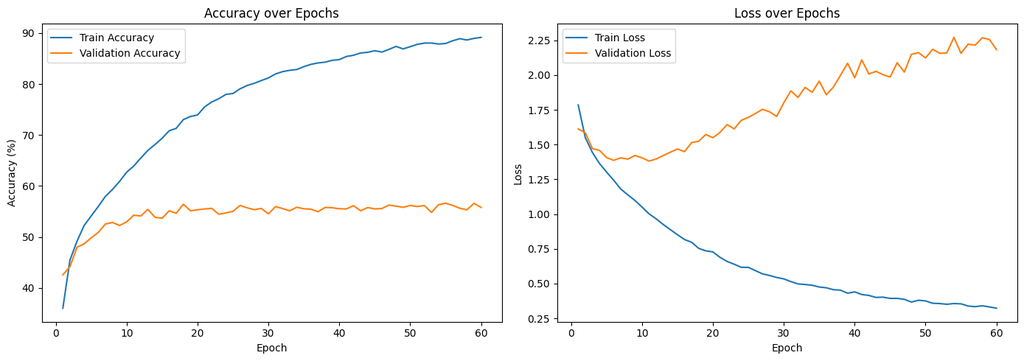

```python
import matplotlib.pyplot as plt

epochs_range = range(1, len(history['train_loss']) + 1)

plt.figure(figsize=(14, 5))

plt.subplot(1, 2, 1)
plt.plot(epochs_range, history['train_acc'], label='Train Accuracy')
plt.plot(epochs_range, history['val_acc'], label='Validation Accuracy')
plt.xlabel('Epoch')
plt.ylabel('Accuracy (%)')
plt.title('Accuracy over Epochs')
plt.legend()

plt.subplot(1, 2, 2)
plt.plot(epochs_range, history['train_loss'], label='Train Loss')
plt.plot(epochs_range, history['val_loss'], label='Validation Loss')
plt.xlabel('Epoch')
plt.ylabel('Loss')
plt.title('Loss over Epochs')
plt.legend()

plt.tight_layout()
plt.show()
```

The model is **overfitting** in these plots.

- **Training Accuracy** keeps increasing and reaches nearly 90%.
- **Validation Accuracy** quickly plateaus around 55–57% and does not improve further, even as training accuracy rises.
- **Training Loss** steadily decreases.
- **Validation Loss** initially decreases, but then starts to **increase** after a few epochs.
- The gap between training and validation accuracy widens as training progresses.
- The increase in validation loss while training loss decreases is a classic sign of overfitting.

## Evaluation

Test your trained model (using the Test Dataloader that you have). Our goal is to reach an accuracy above `60%`

```python
test_loss, test_acc = eval_epoch(model, criterion, testloader)
print(f"Test loss: {test_loss:.4f}; Test accuracy: {test_acc:.2f}%")
```

```
Test loss: 2.1671; Test accuracy: 56.14%
```

# Convolutional Neural Network

## Model

Define your model here from scratch (You are not allowed to use the existing models in pytorch)

**NOTICE:** The model that you will have defined outputs a vector containing 10 numbers (for each class). Define a "feature space" that is a vector of size *N* (where *N > 10*) right before the last layer (You can then have a last layer like `nn.Linear(N, 10)`). See the image below to get a better understanding. We will use this later (we want to access the feature space of a sample when the sample is given to the model). The model tries to learn a representation of the samples in this feature space and we will see how good it could do this in later sections.

[figure not shown]

You are encouraged to learn about the following core components commonly used in convolutional neural networks:

- [`nn.Conv2d`](https://docs.pytorch.org/docs/stable/generated/torch.nn.Conv2d.html)
- [`nn.MaxPool2d`](https://docs.pytorch.org/docs/stable/generated/torch.nn.MaxPool2d.html)

**Reminder**: The model you define should contain 33,500,000 ± 500,000 trainable parameters.

```python
class CNN(nn.Module):
    def __init__(self, num_classes=10):
        super(CNN, self).__init__()
        # VGG-style: 32→64→124, then FC 7936→3072→2048→1024→512→10
        self.features = nn.Sequential(
            nn.Conv2d(3, 32, kernel_size=3, padding=1),  # Conv1: 3x32x32 -> 32x32x32
            nn.BatchNorm2d(32),
            nn.ReLU(inplace=True),
            nn.MaxPool2d(2, 2),                          # Pool1: 32x16x16

            nn.Conv2d(32, 64, kernel_size=3, padding=1), # Conv2: 32x16x16 -> 64x16x16
            nn.BatchNorm2d(64),
            nn.ReLU(inplace=True),
            nn.MaxPool2d(2, 2),                          # Pool2: 64x8x8

            nn.Conv2d(64, 124, kernel_size=3, padding=1),# Conv3: 64x8x8 -> 124x8x8
            nn.BatchNorm2d(124),
            nn.ReLU(inplace=True),
            # No pool after last conv
        )
        self.flatten = nn.Flatten()
        self.feature_space = nn.Sequential(
            nn.Linear(8*8*124, 3072),   # FC1
            nn.ReLU(inplace=True),
            nn.Dropout(0.5),
            nn.Linear(3072, 2048),      # FC2
            nn.ReLU(inplace=True),
            nn.Dropout(0.5),
            nn.Linear(2048, 1024),      # FC3
            nn.ReLU(inplace=True),
            nn.Dropout(0.5),
            nn.Linear(1024, 512),       # FC4
            nn.ReLU(inplace=True),
            nn.Dropout(0.5),
        )
        self.linear = nn.Linear(512, num_classes)  # FC5

    def forward(self, x):
        x = self.features(x)
        x = self.flatten(x)
        x = self.feature_space(x)
        return self.linear(x)
```

## Trainable params

Based on the defined architecture, manually calculate the total number of trainable parameters:

| Layer | In → Out channels | #Neurons (per map) | Params (W + b) |
| --- | --- | --- | --- |
| **Conv1** | 3 → 32 | 3×3×32 | 3×3×3×32 + 32 = **896** |
| BatchNorm2d-1 | 32 | - | 32 + 32 = **64** |
| **Pool1** | – | – | 0 |
| **Conv2** | 32 → 64 | 3×3×64 | 3×3×32×64 + 64 = **18,496** |
| BatchNorm2d-2 | 64 | - | 64 + 64 = **128** |
| **Pool2** | – | – | 0 |
| **Conv3** | 64 → 124 | 3×3×124 | 3×3×64×124 + 124 = **71,548** |
| BatchNorm2d-3 | 124 | - | 124 + 124 = **248** |
| **Flatten** | – | 8×8×124 = 7,936 | 0 |
| **FC1** | 7,936 → 3,072 | – | 7,936×3,072 + 3,072 = **24,382,464** |
| **FC2** | 3,072 → 2,048 | – | 3,072×2,048 + 2,048 = **6,293,504** |
| **FC3** | 2,048 → 1,024 | – | 2,048×1,024 + 1,024 = **2,098,176** |
| **FC4** | 1,024 → 512 | – | 1,024×512 + 512 = **524,800** |
| **FC5** | 512 → 10 | – | 512×10 + 10 = **5,130** |

**Total parameters:** 896 + 64 + 18,496 + 128 + 71,548 + 248 + 24,382,464 + 6,293,504 + 2,098,176 + 524,800 + 5,130 = **33,395,454**

Once you have completed your hand calculation, you can verify your result by running the following cell:

```python
from torchsummary import summary
summary(CNN().to(device), input_size=(3, 32, 32));
```

```
----------------------------------------------------------------
        Layer (type)               Output Shape         Param #
================================================================
            Conv2d-1           [-1, 32, 32, 32]             896
       BatchNorm2d-2           [-1, 32, 32, 32]              64
              ReLU-3           [-1, 32, 32, 32]               0
         MaxPool2d-4           [-1, 32, 16, 16]               0
            Conv2d-5           [-1, 64, 16, 16]          18,496
       BatchNorm2d-6           [-1, 64, 16, 16]             128
              ReLU-7           [-1, 64, 16, 16]               0
         MaxPool2d-8             [-1, 64, 8, 8]               0
            Conv2d-9            [-1, 124, 8, 8]          71,548
      BatchNorm2d-10            [-1, 124, 8, 8]             248
             ReLU-11            [-1, 124, 8, 8]               0
          Flatten-12                 [-1, 7936]               0
           Linear-13                 [-1, 3072]      24,382,464
             ReLU-14                 [-1, 3072]               0
          Dropout-15                 [-1, 3072]               0
           Linear-16                 [-1, 2048]       6,293,504
             ReLU-17                 [-1, 2048]               0
          Dropout-18                 [-1, 2048]               0
           Linear-19                 [-1, 1024]       2,098,176
             ReLU-20                 [-1, 1024]               0
          Dropout-21                 [-1, 1024]               0
           Linear-22                  [-1, 512]         524,800
             ReLU-23                  [-1, 512]               0
          Dropout-24                  [-1, 512]               0
           Linear-25                   [-1, 10]           5,130
================================================================
Total params: 33,395,454
Trainable params: 33,395,454
Non-trainable params: 0
----------------------------------------------------------------
Input size (MB): 0.01
Forward/backward pass size (MB): 1.61
Params size (MB): 127.39
Estimated Total Size (MB): 129.02
----------------------------------------------------------------
```

## Train

### Model instantiation

Create an instance of your model and move it to `device`

```python
model = CNN().to(device)
```

### Criterion & Optimizer

Define `criterion` and `optimizer`

```python
criterion = torch.nn.CrossEntropyLoss()
optimizer = torch.optim.Adam(model.parameters(), lr=0.001)
```

### Train loop

Train your model

Tasks:

- Things that are needed to be printed in each epoch:
  - Number of epoch
  - Train loss
  - Train accuracy
  - Validation loss
  - Validation accuracy
- save train/validation loss and accuracy (of each epoch) in an array for later usage

```python
epochs = 60 # Do not modify
history = {'train_loss':[], 'train_acc':[], 'val_loss':[], 'val_acc':[]}

for epoch in range(epochs):
    train_loss, train_acc = train_epoch(model, criterion, optimizer, trainloader)
    val_loss, val_acc = eval_epoch(model, criterion, valloader)

    history['train_loss'].append(train_loss)
    history['train_acc'].append(train_acc)
    history['val_loss'].append(val_loss)
    history['val_acc'].append(val_acc)

    print(f"(Epoch {epoch + 1} / {epochs}) train loss:{train_loss: .4f}; train acc:{train_acc: .2f}%; val loss:{val_loss: .4f}; val_acc:{val_acc: .2f}%")
```

```
(Epoch 1 / 60) train loss: 1.7047; train acc: 34.49%; val loss: 1.3417; val_acc: 51.06%
(Epoch 2 / 60) train loss: 1.2260; train acc: 56.13%; val loss: 1.2470; val_acc: 55.62%
(Epoch 3 / 60) train loss: 1.0254; train acc: 64.22%; val loss: 0.9178; val_acc: 68.20%
(Epoch 4 / 60) train loss: 0.9118; train acc: 68.81%; val loss: 0.9494; val_acc: 68.10%
(Epoch 5 / 60) train loss: 0.8366; train acc: 71.42%; val loss: 0.8640; val_acc: 70.78%
(Epoch 6 / 60) train loss: 0.7595; train acc: 74.58%; val loss: 0.7960; val_acc: 72.62%
(Epoch 7 / 60) train loss: 0.7054; train acc: 76.00%; val loss: 0.7897; val_acc: 72.90%
(Epoch 8 / 60) train loss: 0.6561; train acc: 77.82%; val loss: 0.7608; val_acc: 75.22%
(Epoch 9 / 60) train loss: 0.6031; train acc: 79.61%; val loss: 0.7270; val_acc: 75.88%
(Epoch 10 / 60) train loss: 0.5555; train acc: 81.20%; val loss: 0.7601; val_acc: 74.38%
(Epoch 11 / 60) train loss: 0.5246; train acc: 82.24%; val loss: 0.7008; val_acc: 77.04%
(Epoch 12 / 60) train loss: 0.4776; train acc: 83.80%; val loss: 0.7111; val_acc: 76.54%
(Epoch 13 / 60) train loss: 0.4444; train acc: 84.88%; val loss: 0.6907; val_acc: 77.10%
(Epoch 14 / 60) train loss: 0.4075; train acc: 86.07%; val loss: 0.6899; val_acc: 77.86%
(Epoch 15 / 60) train loss: 0.3743; train acc: 87.26%; val loss: 0.7031; val_acc: 77.46%
(Epoch 16 / 60) train loss: 0.3570; train acc: 88.00%; val loss: 0.7415; val_acc: 76.60%
(Epoch 17 / 60) train loss: 0.3224; train acc: 88.97%; val loss: 0.8078; val_acc: 75.52%
(Epoch 18 / 60) train loss: 0.3104; train acc: 89.71%; val loss: 0.7748; val_acc: 77.30%
(Epoch 19 / 60) train loss: 0.2757; train acc: 90.62%; val loss: 0.7224; val_acc: 78.62%
(Epoch 20 / 60) train loss: 0.2741; train acc: 90.88%; val loss: 0.7676; val_acc: 77.32%
(Epoch 21 / 60) train loss: 0.2503; train acc: 91.62%; val loss: 0.8853; val_acc: 75.74%
(Epoch 22 / 60) train loss: 0.2400; train acc: 91.94%; val loss: 0.7200; val_acc: 79.26%
(Epoch 23 / 60) train loss: 0.2253; train acc: 92.42%; val loss: 0.8094; val_acc: 76.78%
(Epoch 24 / 60) train loss: 0.2160; train acc: 93.03%; val loss: 0.8203; val_acc: 77.62%
(Epoch 25 / 60) train loss: 0.2035; train acc: 93.23%; val loss: 0.8199; val_acc: 78.92%
(Epoch 26 / 60) train loss: 0.1856; train acc: 93.92%; val loss: 0.7985; val_acc: 78.40%
(Epoch 27 / 60) train loss: 0.1760; train acc: 94.19%; val loss: 0.8354; val_acc: 78.20%
(Epoch 28 / 60) train loss: 0.1645; train acc: 94.64%; val loss: 0.8297; val_acc: 77.78%
(Epoch 29 / 60) train loss: 0.1684; train acc: 94.47%; val loss: 0.8431; val_acc: 79.38%
(Epoch 30 / 60) train loss: 0.1559; train acc: 94.97%; val loss: 0.9336; val_acc: 78.50%
(Epoch 31 / 60) train loss: 0.1487; train acc: 95.08%; val loss: 0.7830; val_acc: 79.04%
(Epoch 32 / 60) train loss: 0.1451; train acc: 95.20%; val loss: 0.9379; val_acc: 78.04%
(Epoch 33 / 60) train loss: 0.1435; train acc: 95.37%; val loss: 0.8151; val_acc: 78.58%
(Epoch 34 / 60) train loss: 0.1278; train acc: 95.91%; val loss: 0.9425; val_acc: 77.18%
(Epoch 35 / 60) train loss: 0.1200; train acc: 96.28%; val loss: 0.8852; val_acc: 79.20%
(Epoch 36 / 60) train loss: 0.1243; train acc: 96.08%; val loss: 0.9241; val_acc: 78.12%
(Epoch 37 / 60) train loss: 0.1248; train acc: 96.06%; val loss: 1.0357; val_acc: 77.08%
(Epoch 38 / 60) train loss: 0.1186; train acc: 96.27%; val loss: 0.9993; val_acc: 77.96%
(Epoch 39 / 60) train loss: 0.1105; train acc: 96.42%; val loss: 1.0365; val_acc: 77.90%
(Epoch 40 / 60) train loss: 0.1062; train acc: 96.61%; val loss: 0.9701; val_acc: 78.40%
(Epoch 41 / 60) train loss: 0.1042; train acc: 96.72%; val loss: 0.9767; val_acc: 79.02%
(Epoch 42 / 60) train loss: 0.1014; train acc: 96.81%; val loss: 0.9353; val_acc: 78.68%
(Epoch 43 / 60) train loss: 0.0987; train acc: 96.92%; val loss: 1.0578; val_acc: 78.68%
(Epoch 44 / 60) train loss: 0.0995; train acc: 96.88%; val loss: 0.9914; val_acc: 78.74%
(Epoch 45 / 60) train loss: 0.0955; train acc: 97.00%; val loss: 0.9734; val_acc: 78.76%
(Epoch 46 / 60) train loss: 0.0938; train acc: 97.02%; val loss: 0.9770; val_acc: 78.42%
(Epoch 47 / 60) train loss: 0.0854; train acc: 97.33%; val loss: 0.9822; val_acc: 79.94%
(Epoch 48 / 60) train loss: 0.0906; train acc: 97.22%; val loss: 0.9627; val_acc: 79.28%
(Epoch 49 / 60) train loss: 0.0893; train acc: 97.19%; val loss: 0.9673; val_acc: 78.96%
(Epoch 50 / 60) train loss: 0.0859; train acc: 97.32%; val loss: 1.0186; val_acc: 78.84%
(Epoch 51 / 60) train loss: 0.0887; train acc: 97.30%; val loss: 1.0305; val_acc: 78.32%
(Epoch 52 / 60) train loss: 0.0859; train acc: 97.39%; val loss: 1.0833; val_acc: 77.30%
(Epoch 53 / 60) train loss: 0.0886; train acc: 97.23%; val loss: 1.0337; val_acc: 79.08%
(Epoch 54 / 60) train loss: 0.0852; train acc: 97.28%; val loss: 1.0373; val_acc: 78.96%
(Epoch 55 / 60) train loss: 0.0784; train acc: 97.64%; val loss: 1.0307; val_acc: 79.10%
(Epoch 56 / 60) train loss: 0.0733; train acc: 97.69%; val loss: 1.1904; val_acc: 78.18%
(Epoch 57 / 60) train loss: 0.0808; train acc: 97.53%; val loss: 1.1099; val_acc: 78.64%
(Epoch 58 / 60) train loss: 0.0809; train acc: 97.52%; val loss: 0.9717; val_acc: 79.32%
(Epoch 59 / 60) train loss: 0.0758; train acc: 97.66%; val loss: 1.0420; val_acc: 78.90%
(Epoch 60 / 60) train loss: 0.0726; train acc: 97.78%; val loss: 1.0486; val_acc: 78.78%
```

### Save Model

Since changes need to be made to the model later on, it is advisable to save your model to avoid having to retrain it in case of any issues.

```python
torch.save(model.state_dict(), "cnn.pth")
```

```python
# To load the previously saved model, simply uncomment the code below.
# model.load_state_dict(torch.load('cnn.pth'))
```

### Visualize Loss and Accuracy plot

Using the arrays that you have (from task 2 in the above section), visualize two plots: Accuracy plot (train and validation together) and Loss plot (train and validation together)

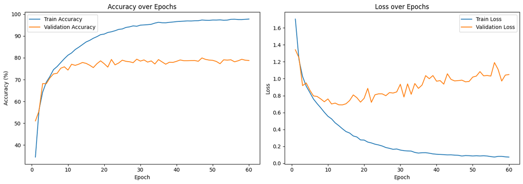

```python
import matplotlib.pyplot as plt

epochs_range = range(1, len(history['train_loss']) + 1)

plt.figure(figsize=(14, 5))

plt.subplot(1, 2, 1)
plt.plot(epochs_range, history['train_acc'], label='Train Accuracy')
plt.plot(epochs_range, history['val_acc'], label='Validation Accuracy')
plt.xlabel('Epoch')
plt.ylabel('Accuracy (%)')
plt.title('Accuracy over Epochs')
plt.legend()

plt.subplot(1, 2, 2)
plt.plot(epochs_range, history['train_loss'], label='Train Loss')
plt.plot(epochs_range, history['val_loss'], label='Validation Loss')
plt.xlabel('Epoch')
plt.ylabel('Loss')
plt.title('Loss over Epochs')
plt.legend()

plt.tight_layout()
plt.show()
```

## Evaluation

Test your trained model (using the Test Dataloader that you have). Our goal is to reach an accuracy above `80%`

```python
test_loss, test_acc = eval_epoch(model, criterion, testloader)
print(f"Test loss: {test_loss:.4f}; Test accuracy: {test_acc:.2f}%")
```

```
Test loss: 1.0959; Test accuracy: 78.41%
```

The **CNN performed significantly better** than the fully connected network. The CNN achieved a much higher training and validation accuracy (train ~98%, val ~78%) compared to the fully connected network (train ~89%, val ~56%).

**Reasons:**

- **CNNs are designed for images:** They use convolutional layers that capture spatial/local patterns (edges, textures, shapes) and are translation-invariant, which is ideal for image data like CIFAR-10.
- **Parameter efficiency:** CNNs share weights across spatial locations, so they can learn more complex features with fewer parameters per layer, reducing overfitting.
- **Fully connected networks ignore spatial structure:** They treat every pixel as independent, so they cannot exploit the 2D structure of images, making them less effective for vision tasks.

**Conclusion:**  
CNNs are much better suited for image classification tasks because they can learn hierarchical and spatial features, leading to better generalization and higher accuracy.

## Visualize incorrectly predicted samples from testset

Visualize *24* random images from testset that are incorrectly predicted by the model. Note that if you used normalization in the transform function for loading the data, you will need to unnormalize the images before displaying them.

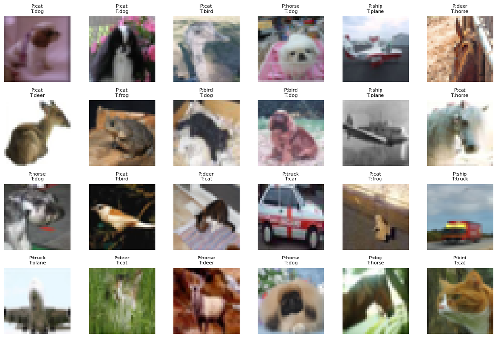

```python
import random

incorrect_samples = []
model.eval()
with torch.no_grad():
    for inputs, labels in testloader:
        inputs, labels = inputs.to(device), labels.to(device)
        outputs = model(inputs)
        _, preds = torch.max(outputs, 1)

        incorrect_mask = preds != labels
        if incorrect_mask.any():
            for img, pred, label in zip(inputs[incorrect_mask], preds[incorrect_mask], labels[incorrect_mask]):
                incorrect_samples.append((img.cpu(), pred.cpu().item(), label.cpu().item()))
        if len(incorrect_samples) >= 24:
            break

incorrect_samples = random.sample(incorrect_samples, 24)

plt.figure(figsize=(12, 8))
for idx, (img, pred, label) in enumerate(incorrect_samples):
    plt.subplot(4, 6, idx + 1)
    img = norminv(img)
    img = img.permute(1, 2, 0).numpy()
    img = np.clip(img, 0, 1)
    plt.imshow(img)
    plt.title(f"P:{classes[pred]}\nT:{classes[label]}", fontsize=8)
    plt.axis('off')
plt.tight_layout()
plt.show()
```

## Exploring the feature space

### Calculate the feature space for all training samples

You have trained and evaluated your model. Now, for each sample in the trainset, calculate it's "feature space" discussed in the model section. The result of this section should be a tensor of size `(45000, N)` saved in a variable (for later usage)

- **Hint:** Pay attension to the `shuffle` attribute of your train dataloader (If needed)

```python
import torch

model.eval()

N = 512
num_samples = len(trainset)
feature_space = torch.zeros((num_samples, N), dtype=torch.float32)
labels_space = torch.zeros(num_samples, dtype=torch.long)

with torch.no_grad():
    idx = 0
    for inputs, labels in DataLoader(trainset, batch_size=64, shuffle=False, num_workers=2, pin_memory=True):
        inputs = inputs.to(device)
        feats = model.features(inputs)
        feats = model.flatten(feats)
        feats = model.feature_space(feats)
        batch_size = feats.shape[0]
        feature_space[idx:idx+batch_size] = feats.cpu()
        labels_space[idx:idx+batch_size] = labels
        idx += batch_size

# feature_space: shape (45000, N)
# labels_space: shape (45000,)
```

### K Nearest Neighbor in feature space

We already have calculated the feature spaces for trainset ($S$) in the previous section. Now we follow these steps to explore the featre space:

1. Get 5 random samples from testset which are correctly predicted by the model.
2. for each sample, calculate it's "feature space" ($X$)
3. for each sample, calculate it's *5* nearest neighbors in "feature space" in the trainset (by comparing $X$ to each row in $S$) and visualize them

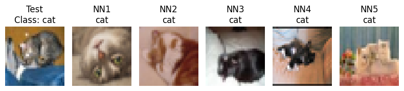

[figure not shown]

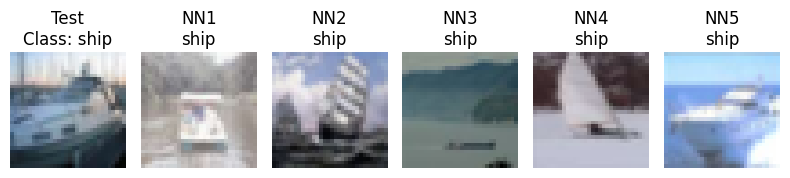

[figure not shown]

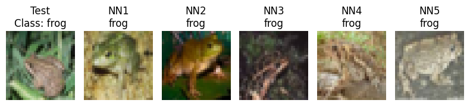

```python
import torch
import numpy as np
import matplotlib.pyplot as plt

# 1.
model.eval()
correct_samples = []
test_features = []
test_labels = []
with torch.no_grad():
    for inputs, labels in testloader:
        inputs, labels = inputs.to(device), labels.to(device)
        outputs = model(inputs)
        _, preds = torch.max(outputs, 1)
        correct_mask = preds == labels
        for img, pred, label in zip(inputs[correct_mask], preds[correct_mask], labels[correct_mask]):
            correct_samples.append((img.cpu(), pred.cpu().item(), label.cpu().item()))
            if len(correct_samples) >= 5:
                break
        if len(correct_samples) >= 5:
            break

# 2.
for img, pred, label in correct_samples:
    img = img.unsqueeze(0).to(device)
    with torch.no_grad():
        feats = model.features(img)
        feats = model.flatten(feats)
        feats = model.feature_space(feats)
    test_features.append(feats.cpu().numpy().squeeze())
    test_labels.append(label)

test_features = np.stack(test_features)  # shape (5, N)

# 3.
from sklearn.metrics.pairwise import euclidean_distances

for i in range(5):
    dists = euclidean_distances(test_features[i].reshape(1, -1), feature_space.numpy())
    nn_indices = np.argsort(dists[0])[:5]
    plt.figure(figsize=(8, 2))
    plt.subplot(1, 6, 1)
    img = norminv(correct_samples[i][0])
    img = img.permute(1, 2, 0).numpy()
    img = np.clip(img, 0, 1)
    plt.imshow(img)
    plt.title("Test\nClass: %s" % classes[test_labels[i]])
    plt.axis('off')
    for j, idx in enumerate(nn_indices):
        neighbor_img, neighbor_label = trainset[idx]
        neighbor_img = norminv(neighbor_img)
        neighbor_img = neighbor_img.permute(1, 2, 0).numpy()
        neighbor_img = np.clip(neighbor_img, 0, 1)
        plt.subplot(1, 6, j + 2)
        plt.imshow(neighbor_img)
        plt.title("NN%d\n%s" % (j+1, classes[labels_space[idx].item()]))
        plt.axis('off')
    plt.tight_layout()
    plt.show()
```

The similarities between the test examples and their nearest neighbors in the feature space are **both visual and semantic**:

Why is there such closeness in the feature space?

- The CNN is trained to **separate classes** and **group similar samples** together in the feature space, so that the final classifier (the last linear layer) can easily distinguish between classes.
- During training, the network learns to map images of the same class to similar feature vectors, and images of different classes to distant points.
- This is a result of the **loss function** (cross-entropy) and the **backpropagation** process, which encourages intra-class compactness and inter-class separation.

Relationship between training and testing data in this space

- **Generalization:** If the model generalizes well, test samples from a class will be close to training samples of the same class in feature space.
- **Cluster Structure:** The feature space forms clusters for each class, containing both training and test samples.
- **Nearest Neighbor Reasoning:** This is why nearest neighbor search in feature space works well for classification and retrieval tasks—the learned space reflects both visual and semantic similarity.

### TSNE

Let's follow these steps to explore feature space even more:

1. Sample $M$ ($2000$ would be enought) random samples from the trainset feature space (calculated in the above sections)
2. Now we have a vector of size `(M, N)` where $N$ is the dimension of the feature space
3. Using TSNE reduce $N$ to $2$ (Now we have a vector of size `(M, 2)`)
4. Visualize the points in a 2D plane (Set color of each point based on it's class)

```python
from sklearn.manifold import TSNE

indices = np.random.randint(0, len(feature_space), 2000)
feature_space = feature_space[indices]
tsne = TSNE(n_components=2, random_state=42)
reduced_space = tsne.fit_transform(feature_space.reshape(feature_space.shape[0], -1).detach().cpu().numpy())
```

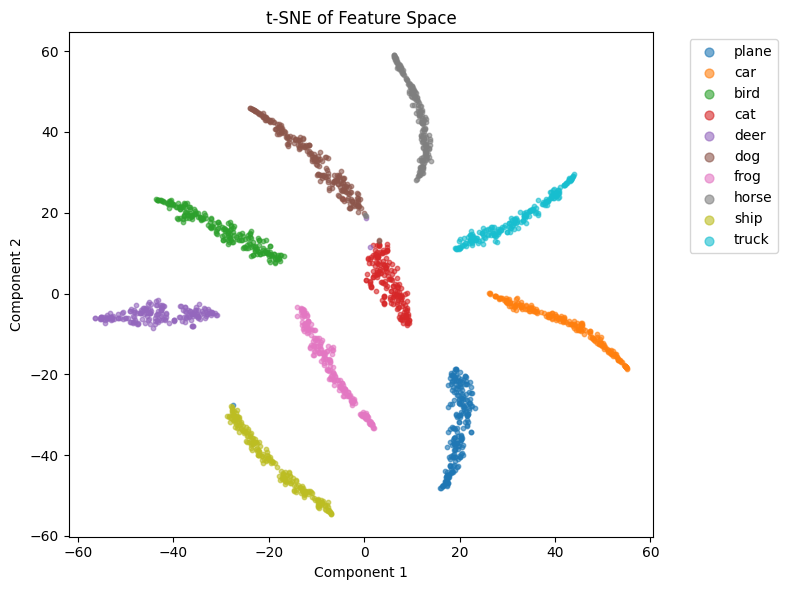

```python
import matplotlib.pyplot as plt

sampled_labels = labels_space[indices].numpy()

plt.figure(figsize=(8, 6))
for i, class_name in enumerate(classes):
    idxs = sampled_labels == i
    plt.scatter(reduced_space[idxs, 0], reduced_space[idxs, 1], label=class_name, alpha=0.6, s=10)
plt.legend(markerscale=2, bbox_to_anchor=(1.05, 1), loc='upper left')
plt.title("t-SNE of Feature Space")
plt.xlabel("Component 1")
plt.ylabel("Component 2")
plt.tight_layout()
plt.show()
```

The t-SNE plot of the model's feature space shows that **samples from the same class form distinct, well-separated clusters**. This means that the CNN has learned to map images of the same class to nearby points in the feature space, while pushing images from different classes far apart.

**Reason:**  
This clustering happens because the model is trained with a classification loss (cross-entropy), which encourages the network to produce similar feature vectors for samples of the same class and dissimilar vectors for different classes. The last linear layer can then easily separate these clusters for classification. As a result, the feature space reflects both the semantic and visual similarities of the data, making it highly structured and class-discriminative.

### Feature Map

In this part, we are going to visualize the output of one of the convolutional layers to see what features they focus on.

First, let's select a random image from dataset.

Feature maps provide insight into **what the convolutional layers are detecting at different stages of the network**. By visualizing feature maps, you can:

- **Understand which patterns or regions the network focuses on:** Early layers often detect simple features like edges or colors, while deeper layers capture more complex shapes or object parts.
- **Diagnose model behavior:** Feature maps can reveal if the model is ignoring important regions or focusing on irrelevant background.
- **Detect dead filters:** If some feature maps are always zero or constant, it may indicate unused filters.
- **Interpretability:** They help make the model’s decision process more transparent by showing how input information is transformed layer by layer.

Overall, feature maps help you analyze, debug, and interpret the internal workings of convolutional neural networks.

```python
image = trainset[3][0]
```

Now, we are going to *clip* our model at different points to get different intermediate representation.

- Clip your model at least at one point and plot the filters output. You can use the output of first Resnet block.

In order to clip the model, you can use `model.children()` method. For example, to get output only after the first 2 layers, you can do:

```
clipped = nn.Sequential(
    *list(model.children()[:2])
)
intermediate_output = clipped(input)
```

```python
img = image.unsqueeze(0).to(device)

# Clip the model after the first conv block (features[0:3] = Conv2d, BatchNorm2d, ReLU)
clipped = nn.Sequential(*list(model.features.children())[:3])
with torch.no_grad():
    intermediate_output = clipped(img)
```

```python
intermediate_output.shape
```

```
torch.Size([1, 32, 32, 32])
```

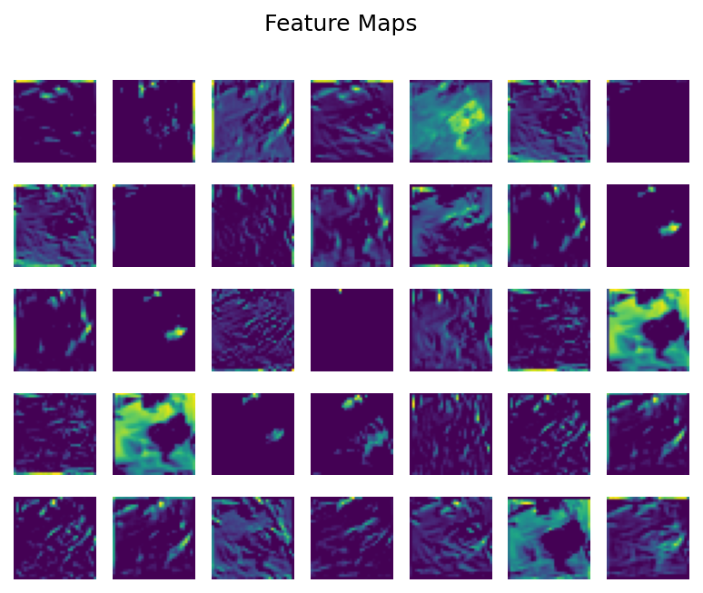

```python
import matplotlib.pyplot as plt

def plot_intermediate_output(result, title=None):
    """
    Plots the intermediate output of shape
    N_FILTERS x H x W
    """
    plt.rcParams['figure.dpi'] = 150
    n_filters = result.shape[1]
    N = int(math.sqrt(n_filters))
    M = (n_filters + N - 1) // N
    assert N * M >= n_filters

    fig, axs = plt.subplots(N, M)
    fig.suptitle(title)

    for i in range(N):
        for j in range(M):
            if i*N + j < n_filters:
                axs[i][j].imshow(result[0, i*N + j].cpu().detach())
                axs[i][j].axis('off')

plot_intermediate_output(intermediate_output, title='Feature Maps')
```

**Note:** You are expected to analyze all results presented in this notebook and thoughtfully consider the underlying reasons behind them. Be prepared to discuss your insights during the **in-person review session**. A written report is not required.